# A monocyte eQTL analysis using ATLASQTL

Hélène Ruffieux

12/29/2020

### Context

This R markdown document consists of a short tutorial for performing expression quantitative trait locus (eQTL) analyses using the Bayesian hierarchical mapping approach ATLASQTL whose R package is available [here](https://github.com/hruffieux/atlasqtl). It is an online material for the book chapter “Variable selection for hierarchically-related outcomes: models and algorithms” (Ruffieux, Bottolo, and Richardson 2021) published in Tadesse, M.G. and Vannucci, M. (2021). It uses data adapted from the monocyte eQTL analysis illustration discussed in Section 1.3.2.

ATLASQTL implements a hierarchically sparse regression approach for modelling jointly several thousands of genetic variants and molecular quantitative traits using an efficient variational inference algorithm augmented with simulated annealing schemes. Although the example presented below involves transcriptomic expression, ATLASQTL can be used for any other type of molecular QTL problem, with proteomic, lipodomic or metabolic traits.

### Data

The data used in this example consist of synthetic genotyping data which emulate the genotypes (single nucleotide polymorphisms - SNPs) for the *LYZ* gene region (the genotypes require setting up a data access agreement and hence cannot be publicly shared). The expression data consist of resting (unstimulated) monocyte levels, monocyte levels obtained from three stimulated conditions (IFNg, LPS2h, LPS24h) and B-cells; see Section 1.3.2 of the book chapter for a full description. To each of these transcriptomic datasets corresponds a separate eQTL problem.

As we are using synthetic SNP data, we need to simulate genetic association between the SNPs and the expression levels from each dataset. The two steps:

1. generation of synthetic SNPs from the real SNPs and
2. modification of the expression levels to create genetic associations

are done using our in-house R package `echoseq` available [here](https://github.com/hruffieux/echoseq). While 1) requires access to the real genotyping data, 2) can be run using the R script `prepare_data.R` available in [this repository](https://github.com/hruffieux/bayesian_variable_selection_book_chapter) - alternatively, one can directly use the `prepared_data.RData` R object file which contains the datasets ready-to-use for this tutorial.

### Installation

Please install the R package `atlasqtl` following the instructions provided [here](https://github.com/hruffieux/atlasqtl#installation). Note that the GSL library must be installed prior to installing the package.

### Analysis code

We first set the data, output and main directories for the analysis (please edit according to your own setup):

```r
rm(list = ls())

CORE_DIR <- file.path(Sys.getenv("CORE_DIR"), "bayesian_variable_selection_book_chapter/")

data_dir <- file.path(CORE_DIR, "data/")
out_dir <- file.path(CORE_DIR, "output/")
main_dir <- file.path(CORE_DIR, "scripts/")
setwd(main_dir)
```

We next set a seed for reproducibility. The random generator “L’Ecuyer-CMRG” ensures reproducibility when parallel processes are used.

```r
RNGkind("L'Ecuyer-CMRG")
seed <- 1
set.seed(seed)
```

The SNP and monocyte expression data are loaded (see Data Section above for details).

```r
load(file.path(data_dir, "prepared_data.RData"))
ls()
```

```
## [1] "CORE_DIR"  "data_dir"  "list_data" "main_dir"  "out_dir"   "seed"
```

We will run a total of five different eQTL analyses (for resting monocytes, IFNg, LPS2h, LPS24h monocytes and B-cells); the vector `vec_type` gathers the names of these eQTL problems. The five analyses can be run in parallel by first specifying the number of CPUs to be used. Here we are using the $4$ cores of our laptop, but please change this number according to your setup. Setting `n_cpus <- 1` corresponds to a serial execution (e.g., needed for Windows users).

```r
vec_type <- names(list_data)

n_cpus <- 4

p <- unique(sapply(list_data, function(ll_type) ncol(ll_type$snps)))
stopifnot(length(p) == 1) # all datasets involve the same number of SNPs

q <- unique(sapply(list_data, function(ll_type) ncol(ll_type$expr)))
stopifnot(length(q) == 1) # all datasets involve the same number of traits

n <- sapply(list_data, function(ll_type) nrow(ll_type$expr))
n_check <- sapply(list_data, function(ll_type) nrow(ll_type$expr))
stopifnot(all.equal(n, n_check)) # same number of samples for SNPs and traits within each eQTL problem
rm(n_check)

vec_type
```

```
## [1] "bcells" "unstim" "ifng"   "lps2h"  "lps24h"
```

```r
p # number of SNPs
```

```
## [1] 100
```

```r
q # number of traits in each eQTL problem
```

```
## [1] 1751
```

```r
n # sample sizes in the five eQTL problems
```

```
## bcells unstim   ifng  lps2h lps24h
##    275    413    366    260    321
```

When `bool_save <- TRUE`, the analysis output is saved to a dedicated directory and the output and error messages are redirected to text files there.

```r
bool_save <- FALSE

if( bool_save ){
  res_dir <- paste0(out_dir, "atlasqtl_runs_seed_", seed, "/")
  dir.create(res_dir, showWarnings = FALSE)

  sink(paste(res_dir, "out.txt", sep = ""), append = F,
       split = T, type = "output")
  sink(file(paste(res_dir, "err.txt", sep = ""), open = "wt"),
       type = "message")
}
```

ATLASQTL requires the specification of just two hyperparameters via the elicitation of a prior mean and variance for the number of SNPs associated with each trait. The impact of these choices on the analysis is limited, and essentially non existent once a permutation-based FDR threshold is employed (where the “null-case” permutation runs use the same prior specifications).

The remaining model parameters are inferred in a fully Bayesian fashion. In particular, the hotspot propensity is assigned a horseshoe prior which circumvent ad-hoc specifications of top-level variances (a case where inference is prone to strong biases). Our specification also has desirable multiplicity adjustment properties for dealing with the large-response case, see Ruffieux et al. (2020).

```r
mu_t <- 1 # prior number of SNPs expected to be associated with each expression level
sd_t <- 2 # prior standard deviation for this number
```

The next chunk runs the five ATLASQTL analyses in parallel, also storing the overall run time. We are using the default annealing setting, namely a geometric schedule on the inverse temperature, with initial temperature of $2$ and $10$ different temperatures. This specification, as well as alternative options, are described in greater details on the help page of the function, by running `?atlasqtl`. A number of additional settings (e.g., tolerance, maximum number of iterations, checkpointing, etc.) are also detailed there.

Note that the parallel execution relies on the R package `parallel` which has already been installed as part of the `atlasqtl` installation.

```r
# Takes about 1min 30sec on a standard laptop with 4 CPUs
#
require(atlasqtl)
rt <- system.time(list_out <- parallel::mclapply(vec_type, function(type) {

  snps <- list_data[[type]]$snps
  expr <- list_data[[type]]$expr

  stopifnot(rownames(snps) == rownames(expr))

  atlasqtl(Y = expr, X = snps,
           p0 = c(mu_t, sd_t^2),
           add_collinear_back = TRUE)

}, mc.cores = n_cpus))

names(list_out) <- vec_type
print(rt)
```

```
##    user  system elapsed
##  67.947   5.203  36.096
```

The object returned by `atlasqtl` contains a range of useful posterior quantities, which can be employed to assess:

- the pairwise associations between each pair of SNP and trait: using the variational posterior probabilities (PPIs) stored in `gam_vb` ($p \times q$ matrix) and the variational posterior means of the regression estimates stored in `beta_vb` ($p \times q$ matrix);
- the hotspot propensities: using the variational posterior mean of $\theta_s$ stored in `theta_vb` (vector of length $p$).

It also contains diagnostic values on the final status of convergence and number of iterations used for the coordinate ascent variational algorithm.

```r
atlasqtl_unstim <- list_out$unstim
summary(as.vector(atlasqtl_unstim$gam_vb)) # PPIs, pr(gamma = 1 | y)
```

```
##      Min.   1st Qu.    Median      Mean   3rd Qu.      Max.
## 0.0001882 0.0002576 0.0003345 0.0037925 0.0007167 1.0000000
```

```r
summary(as.vector(atlasqtl_unstim$beta_vb)) # E(beta | y)
```

```
##       Min.    1st Qu.     Median       Mean    3rd Qu.       Max.
## -0.5867404 -0.0000046  0.0000000  0.0000206  0.0000046  0.6948798
```

```r
summary(atlasqtl_unstim$theta_vb) # E(theta | y)
```

```
##       Min.    1st Qu.     Median       Mean    3rd Qu.       Max.
## -0.0003263 -0.0003076 -0.0002945  0.0403932 -0.0002676  1.6039692
```

If `bool_save = TRUE`, the full output is saved in the directory created above.

```r
if (bool_save) {
  save(list_out, rt, file = paste(res_dir, "output.RData", sep = ""))
}
```

Finally, we display a Manhattan-type plot which indicates the position of the hotspots, as estimated in the five different eQTL analyses. Recall that we are using simulated data so these results do not reflect the real data analysis in Section 1.3.2 of the book chapter, although the code is similar to that used for producing Figure 1.4.

Also note that the analyses of the book chapter implement a permutation analyses to compute calibrated Bayesian FDR thresholds on the PPIs; we skip this for computational economy and use an arbitrary threshold instead. The procedure to derive these permutation-based FDR threshold is described in details in Ruffieux et al. (2017) and Ruffieux et al. (2020).

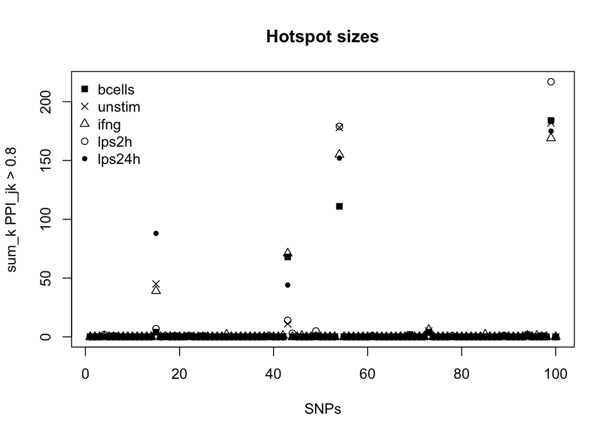

```r
thres <- 0.8
list_rs_thres <- lapply(list_out, function(ll_type) rowSums(ll_type$gam_vb>thres))

vec_pch <- c(15, 4, 2, 21, 20)

plot(list_rs_thres[[1]], pch = vec_pch[1],
     ylim = c(0, max(unlist(list_rs_thres))),
     main = "Hotspot sizes",
     xlab = "SNPs",
     ylab = paste0("sum_k PPI_jk > ", thres))
for (type_id in 2:5) {
  points(list_rs_thres[[type_id]], pch = vec_pch[type_id])
}
legend("topleft", legend = vec_type, pch = vec_pch, bty = "n")
```

# References

Ruffieux, H., L. Bottolo, and S. Richardson. 2021. “Variable Selection for Hierarchically-Related Outcomes: Models and Algorithms.” In *Handbook of Bayesian Variable Selection*, edited by Tadesse, M.G. and Vannucci, M. Chapman & Hall/CRC.

Ruffieux, H., A. C. Davison, J. Hager, J. Inshaw, B. Fairfax, S. Richardson, and L. Bottolo. 2020. “A Global-Local Approach for Detecting Hotspots in Multiple Response Regression.” *The Annals of Applied Statistics* 14: 905–28.

Ruffieux, H., A. C. Davison, J. Hager, and I. Irincheeva. 2017. “Efficient Inference for Genetic Association Studies with Multiple Outcomes.” *Biostatistics* 18: 618–36.

Tadesse, M.G. and Vannucci, M. 2021. *Handbook of Bayesian Variable Selection*. Chapman & Hall/CRC.